# Homework 1

Erdem Cagri Utku - IE360 - Spring 2020

18 04 2020

# 1.Introduction

The investments in the conctruction sector in the recent times have been contraversial in Turkey, because of the similarity of the current situation of the sector to that of pre-“Great Depression” period of the US. What happened before the Great Depression and, allegedly caused it, was the speculative expansion of construction sector, that is the rise of prices and sales of houses inorganically<sup>1</sup> by means of the mortgage credits<sup>2</sup> provided by banks. This “housing bubble” eventually resulted in houses seized by banks which desperately look for buyers at dramatically lower prices. The aim of this analysis is to answer the question of “Is the expansion of construction sector parallel to the basic statistics of prosperity in Turkey,or is it an inorganic and dangerous expansion like the example of US in Great Depression?”. For that purpose the data to be examined is, first of all, the indicators of the financial situation of people of Turkey, such as the unemployement rates, labour force participation and consumer price indices, secondly the proportion of GDP coming from the construction sector, and thirdly the number of construction and sales of the houses along with their unit prices in Turkey.

# 2. Data Analysis

## 2.1 Data Manupilation and Generation of xts Objects

Since all of the data could not be downloaded at the same time four excel files will be read separately and merged as a single xts object.

First of all, the data is read and examined below.

```r
library(xts)
library(readxl)
library(gsubfn)
dat1 <- read_excel("EVDS.xlsx")
dat2 <- read_excel("EVDS (1).xlsx")
dat3 <- read_excel("EVDS (2).xlsx")
```

```
## * `` -> ...3
```

```r
dat4 <- read_excel("EVDS (3).xlsx")
```

```
## * `` -> ...3
```

```r
head(dat1)
```

```
## # A tibble: 6 x 9
##   Tarih `TP AKONUTSAT1 ~ `TP AKONUTSAT3 ~ `TP DISKONSAT T~ `TP FG J0`
##   <chr> <chr>            <chr>            <chr>                 <dbl>
## 1 2002~ <NA>             <NA>             <NA>                   NA
## 2 2002~ <NA>             <NA>             <NA>                   NA
## 3 2002~ <NA>             <NA>             <NA>                   NA
## 4 2002~ <NA>             <NA>             <NA>                   NA
## 5 2003~ <NA>             <NA>             <NA>                   94.8
## 6 2003~ <NA>             <NA>             <NA>                   96.2
## # ... with 4 more variables: `TP FG B01 95` <dbl>, `TP HKFE01` <dbl>, `TP
## #   TCBF01 TURKIYE` <dbl>, `TP TIG06` <dbl>
```

```r
head(dat2)
```

```
## # A tibble: 6 x 3
##   Tarih   `TP TIG07` `TP TIG08`
##   <chr>   <chr>      <chr>
## 1 2002-01 <NA>       <NA>
## 2 2002-02 <NA>       <NA>
## 3 2002-03 <NA>       <NA>
## 4 2002-04 <NA>       <NA>
## 5 2002-05 <NA>       <NA>
## 6 2002-06 <NA>       <NA>
```

```r
head(dat3)
```

```
## # A tibble: 6 x 3
##   Tarih   `TP GSYIH04 IFK ZH` ...3
##   <chr>   <chr>               <chr>
## 1 2002-Q1 5582784.25          <NA>
## 2 2002-Q2 8407791.1300000008  <NA>
## 3 2002-Q3 8515874.6699999999  <NA>
## 4 2002-Q4 9258237.6699999999  <NA>
## 5 2003-Q1 6742754.4900000002  <NA>
## 6 2003-Q2 9600337.6600000001  <NA>
```

```r
head(dat4)
```

```
## # A tibble: 6 x 3
##   Tarih   `TP GSYIH26 GY CF` ...3
##   <chr>   <chr>              <chr>
## 1 2002-Q1 69108200.109999999 <NA>
## 2 2002-Q2 83561899.670000002 <NA>
## 3 2002-Q3 101675779.72       <NA>
## 4 2002-Q4 105012991.92       <NA>
## 5 2003-Q1 96288944.700000003 <NA>
## 6 2003-Q2 111329662.39       <NA>
```

```r
dat3<-dat3[, -3]
dat4<-dat4[, -3]
```

The NA values in the dates of all four data are extracted manually:

```r
dat1$Tarih
```

```
##   [1] "2002-09"              "2002-10"              "2002-11"
##   [4] "2002-12"              "2003-01"              "2003-02"
##   [7] "2003-03"              "2003-04"              "2003-05"
##  [10] "2003-06"              "2003-07"              "2003-08"
##  [13] "2003-09"              "2003-10"              "2003-11"
##  [16] "2003-12"              "2004-01"              "2004-02"
##  [19] "2004-03"              "2004-04"              "2004-05"
##  [22] "2004-06"              "2004-07"              "2004-08"
##  [25] "2004-09"              "2004-10"              "2004-11"
##  [28] "2004-12"              "2005-01"              "2005-02"
##  [31] "2005-03"              "2005-04"              "2005-05"
##  [34] "2005-06"              "2005-07"              "2005-08"
##  [37] "2005-09"              "2005-10"              "2005-11"
##  [40] "2005-12"              "2006-01"              "2006-02"
##  [43] "2006-03"              "2006-04"              "2006-05"
```

[output cut: 73 more lines]

```r
dat1<-dat1[-c(212:263),]
dat2$Tarih
```

```
##   [1] "2002-01"             "2002-02"             "2002-03"
##   [4] "2002-04"             "2002-05"             "2002-06"
##   [7] "2002-07"             "2002-08"             "2002-09"
##  [10] "2002-10"             "2002-11"             "2002-12"
##  [13] "2003-01"             "2003-02"             "2003-03"
##  [16] "2003-04"             "2003-05"             "2003-06"
##  [19] "2003-07"             "2003-08"             "2003-09"
##  [22] "2003-10"             "2003-11"             "2003-12"
##  [25] "2004-01"             "2004-02"             "2004-03"
##  [28] "2004-04"             "2004-05"             "2004-06"
##  [31] "2004-07"             "2004-08"             "2004-09"
##  [34] "2004-10"             "2004-11"             "2004-12"
##  [37] "2005-01"             "2005-02"             "2005-03"
##  [40] "2005-04"             "2005-05"             "2005-06"
##  [43] "2005-07"             "2005-08"             "2005-09"
```

[output cut: 64 more lines]

```r
dat2<-dat2[-c(218:236),]
dat3$Tarih
```

```
##  [1] "2002-Q1"             "2002-Q2"             "2002-Q3"
##  [4] "2002-Q4"             "2003-Q1"             "2003-Q2"
##  [7] "2003-Q3"             "2003-Q4"             "2004-Q1"
## [10] "2004-Q2"             "2004-Q3"             "2004-Q4"
## [13] "2005-Q1"             "2005-Q2"             "2005-Q3"
## [16] "2005-Q4"             "2006-Q1"             "2006-Q2"
## [19] "2006-Q3"             "2006-Q4"             "2007-Q1"
## [22] "2007-Q2"             "2007-Q3"             "2007-Q4"
## [25] "2008-Q1"             "2008-Q2"             "2008-Q3"
## [28] "2008-Q4"             "2009-Q1"             "2009-Q2"
## [31] "2009-Q3"             "2009-Q4"             "2010-Q1"
## [34] "2010-Q2"             "2010-Q3"             "2010-Q4"
## [37] "2011-Q1"             "2011-Q2"             "2011-Q3"
## [40] "2011-Q4"             "2012-Q1"             "2012-Q2"
## [43] "2012-Q3"             "2012-Q4"             "2013-Q1"
## [46] "2013-Q2"             "2013-Q3"             "2013-Q4"
## [49] "2014-Q1"             "2014-Q2"             "2014-Q3"
## [52] "2014-Q4"             "2015-Q1"             "2015-Q2"
## [55] "2015-Q3"             "2015-Q4"             "2016-Q1"
## [58] "2016-Q2"             "2016-Q3"             "2016-Q4"
## [61] "2017-Q1"             "2017-Q2"             "2017-Q3"
## [64] "2017-Q4"             "2018-Q1"             "2018-Q2"
## [67] "2018-Q3"             "2018-Q4"             "2019-Q1"
## [70] "2019-Q2"             "2019-Q3"             "2019-Q4"
## [73] NA                    NA                    "Series Descriptions"
## [76] "TP.GSYIH04.IFK.ZH"   NA                    "Notes"
## [79] "TP.GSYIH04.IFK.ZH"   NA                    NA
## [82] NA                    NA                    NA
```

```r
dat3<-dat3[-c(73:84),]
dat4$Tarih
```

```
##  [1] "2002-Q1"             "2002-Q2"             "2002-Q3"
##  [4] "2002-Q4"             "2003-Q1"             "2003-Q2"
##  [7] "2003-Q3"             "2003-Q4"             "2004-Q1"
## [10] "2004-Q2"             "2004-Q3"             "2004-Q4"
## [13] "2005-Q1"             "2005-Q2"             "2005-Q3"
## [16] "2005-Q4"             "2006-Q1"             "2006-Q2"
## [19] "2006-Q3"             "2006-Q4"             "2007-Q1"
## [22] "2007-Q2"             "2007-Q3"             "2007-Q4"
## [25] "2008-Q1"             "2008-Q2"             "2008-Q3"
## [28] "2008-Q4"             "2009-Q1"             "2009-Q2"
## [31] "2009-Q3"             "2009-Q4"             "2010-Q1"
## [34] "2010-Q2"             "2010-Q3"             "2010-Q4"
## [37] "2011-Q1"             "2011-Q2"             "2011-Q3"
## [40] "2011-Q4"             "2012-Q1"             "2012-Q2"
## [43] "2012-Q3"             "2012-Q4"             "2013-Q1"
## [46] "2013-Q2"             "2013-Q3"             "2013-Q4"
## [49] "2014-Q1"             "2014-Q2"             "2014-Q3"
## [52] "2014-Q4"             "2015-Q1"             "2015-Q2"
## [55] "2015-Q3"             "2015-Q4"             "2016-Q1"
## [58] "2016-Q2"             "2016-Q3"             "2016-Q4"
## [61] "2017-Q1"             "2017-Q2"             "2017-Q3"
## [64] "2017-Q4"             "2018-Q1"             "2018-Q2"
## [67] "2018-Q3"             "2018-Q4"             "2019-Q1"
## [70] "2019-Q2"             "2019-Q3"             "2019-Q4"
## [73] NA                    NA                    "Series Descriptions"
## [76] "TP.GSYIH26.GY.CF"    NA                    "Notes"
## [79] "TP.GSYIH26.GY.CF"    NA                    NA
## [82] NA                    NA                    NA
```

```r
dat4<-dat4[-c(73:84),]
```

Now, let’s convert all of the data to xts format, for the “Tarih” variable to be read as a date extra operations have been applied:

```r
xts1<-xts(dat1[-1], order.by = as.Date(as.yearmon(dat1$Tarih)))
xts2<-xts(dat2[-1], order.by = as.Date(as.yearmon(dat2$Tarih)))
xts3<-xts(dat3[-1], order.by = as.Date(as.yearqtr(gsub("Q","",dat3$Tarih))))
xts4<-xts(dat4[-1], order.by = as.Date(as.yearqtr(gsub("Q","",dat4$Tarih))))
tail(xts1)
```

```
##            TP AKONUTSAT1 TOPLAM TP AKONUTSAT3 TOPLAM TP DISKONSAT TOPLAM
## 2019-10-01 "142810"             "50181"              "4272"
## 2019-11-01 "138372"             "48909"              "3988"
## 2019-12-01 "202074"             "75480"              "5298"
## 2020-01-01 "113615"             "36040"              "3907"
## 2020-02-01 "118753"             "37303"              "4005"
## 2020-03-01 "108670"             "34089"              "3036"
##            TP FG J0 TP FG B01 95 TP HKFE01 TP TCBF01 TURKIYE TP TIG06
## 2019-10-01 "435.59" "21816.8"    "116.00"  "2848.41"         "53.00"
## 2019-11-01 "437.25" "21914.7"    "117.10"  "2885.67"         "52.50"
## 2019-12-01 "440.50" "22149.3"    "118.76"  "2930.51"         "51.80"
## 2020-01-01 "446.45" "22278.1"    "120.93"  "2999.64"         "51.00"
## 2020-02-01 "448.02" "22530.4"    "123.71"  "3061.24"         NA
## 2020-03-01 "450.58" "22604.2"    NA        NA                NA
```

```r
tail(xts2)
```

```
##            TP TIG07 TP TIG08
## 2019-08-01 "14"     "16.7"
## 2019-09-01 "13.8"   "16.399999999999999"
## 2019-10-01 "13.4"   "15.7"
## 2019-11-01 "13.3"   "15.4"
## 2019-12-01 "13.7"   "15.8"
## 2020-01-01 "13.8"   "15.7"
```

```r
tail(xts3)
```

```
##            TP GSYIH04 IFK ZH
## 2018-07-01 "33922918.350000001"
## 2018-10-01 "30818716.829999998"
## 2019-01-01 "24663446.18"
## 2019-04-01 "29283595.82"
## 2019-07-01 "31123761.460000001"
## 2019-10-01 "29640044.789999999"
```

```r
tail(xts4)
```

```
##            TP GSYIH26 GY CF
## 2018-07-01 "1026648922.65"
## 2018-10-01 "1017190008.72"
## 2019-01-01 "922000418.20000005"
## 2019-04-01 "1022645667.05"
## 2019-07-01 "1145879646.72"
## 2019-10-01 "1189855413.1600001"
```

The data in xts 3 and xts 4 are quarterly, therefore, the data in xts1 and xts2 should be made quaterly as well.

For xts1, the first three column is related to house sales, so they should be summed; and the rest of the columns are related to price indices and labour force particioation rate, these can be averaged.

```r
xts1<-xts1[-c(1,2),]
ep <- endpoints(xts1, on = "months", k=3)
xts_Q_1<-period.apply(xts1[, c(4:8)], INDEX = ep, FUN = mean)
xts_Q_2<-period.apply(xts1[, c(1:3)], INDEX = ep, FUN = mean)
coredata(xts_Q_2)<-coredata(xts_Q_2)*3
tail(xts_Q_2)
```

```
##            TP AKONUTSAT1 TOPLAM TP AKONUTSAT3 TOPLAM TP DISKONSAT TOPLAM
## 2019-01-01             299408.0               141730             12400.0
## 2019-04-01             279567.0               114595             10170.0
## 2019-07-01             255528.0                99442             10806.0
## 2019-10-01             400251.0               142208             12053.0
## 2020-01-01             454061.0               160429             13193.0
## 2020-03-01             341134.5               107088             10561.5
```

```r
tail(xts_Q_1)
```

```
##            TP FG J0 TP FG B01 95 TP HKFE01 TP TCBF01 TURKIYE TP TIG06
## 2019-01-01 395.8100     19614.23  108.2800          2819.153 52.53333
## 2019-04-01 403.7167     20236.37  108.9733          2702.983 52.76667
## 2019-07-01 415.4633     20739.33  111.2033          2755.117 53.33333
## 2019-10-01 428.4900     21483.83  115.1833          2825.490 53.46667
## 2020-01-01 441.4000     22114.03  118.9300          2938.607 51.76667
## 2020-03-01 449.3000     22567.30        NA                NA       NA
```

For xts2, both of the columns can be averaged over the quarters since both of them are the unemployement rate statistics.

```r
xts2<-xts2[-1,]
ep2 <- endpoints(xts2, on = "months", k=3)
xts_Q_3<-period.apply(xts2, INDEX = ep2, FUN = mean)
```

Now that all xts variables have the same type of dates, all the data at hand can be merged:

```r
xts_comb<-merge(xts_Q_2, xts_Q_1, xts_Q_3, xts3, xts4, join = "inner")
```

Some of the columns in the xts_comb object are NA before 2013. Since these variables are the essential ones for the analysis, the rows with an NA in a column will be deleted by the following command.

```r
xts_comb<-na.omit(xts_comb)
```

As the last step for this part, the row names will be made understandable.

```r
names(xts_comb)
```

```
##  [1] "TP.AKONUTSAT1.TOPLAM" "TP.AKONUTSAT3.TOPLAM" "TP.DISKONSAT.TOPLAM"
##  [4] "TP.FG.J0"             "TP.FG.B01.95"         "TP.HKFE01"
##  [7] "TP.TCBF01.TURKIYE"    "TP.TIG06"             "TP.TIG07"
## [10] "TP.TIG08"             "TP.GSYIH04.IFK.ZH"    "TP.GSYIH26.GY.CF"
```

```r
names(xts_comb)<-c("total.house.sales(piece)", "first.sale.house(piece)", "house.sales.foreigners(piece)","consumer.price.index","CPI.wage.earners","Residential.Property.Price.Index","Housing.Unit.Prices","Labour.force.participation.rate","Unemployment.rate","Non-agricultural.unemployment.rate","construction.GDP","GDP")
```

Consequently, this is how data finally looks like:

```r
head(xts_comb)
```

```
##            total.house.sales(piece) first.sale.house(piece)
## 2013-04-01                   281856                  123806
## 2013-07-01                   306321                  138618
## 2013-10-01                   263104                  120958
## 2014-01-01                   306104                  146739
## 2014-04-01                   253824                  117612
## 2014-07-01                   268414                  123449
##            house.sales.foreigners(piece) consumer.price.index CPI.wage.earners
## 2013-04-01                          2625             218.6567         11032.00
## 2013-07-01                          2835             221.4200         11329.60
## 2013-10-01                          2936             224.6867         11368.07
## 2014-01-01                          4104             230.1700         11621.23
## 2014-04-01                          3987             237.3633         11938.70
## 2014-07-01                          4786             242.1867         12240.60
##            Residential.Property.Price.Index Housing.Unit.Prices
## 2013-04-01                         58.42000            1352.283
## 2013-07-01                         60.57333            1406.393
## 2013-10-01                         62.02000            1449.607
## 2014-01-01                         63.66333            1499.447
## 2014-04-01                         65.75333            1547.010
## 2014-07-01                         68.32667            1628.687
##            Labour.force.participation.rate Unemployment.rate
## 2013-04-01                        47.90000          9.266667
## 2013-07-01                        49.23333          8.300000
## 2013-10-01                        48.76667          9.100000
## 2014-01-01                        47.86667          9.733333
## 2014-04-01                        49.90000          9.633333
## 2014-07-01                        51.26667          9.233333
##            Non-agricultural.unemployment.rate construction.GDP       GDP
## 2013-04-01                           11.10000         25436311 441539543
## 2013-07-01                           10.23333         28244964 491263794
## 2013-10-01                           11.13333         27534728 491085107
## 2014-01-01                           11.46667         23913756 451269184
## 2014-04-01                           11.50000         25377462 487151068
## 2014-07-01                           11.26667         28542197 548625835
```

## 2.2 Data Visualisation and Analysis

First of all, the financial situation of people in Turkey can be examined by labour force participation and Unemployement rates:

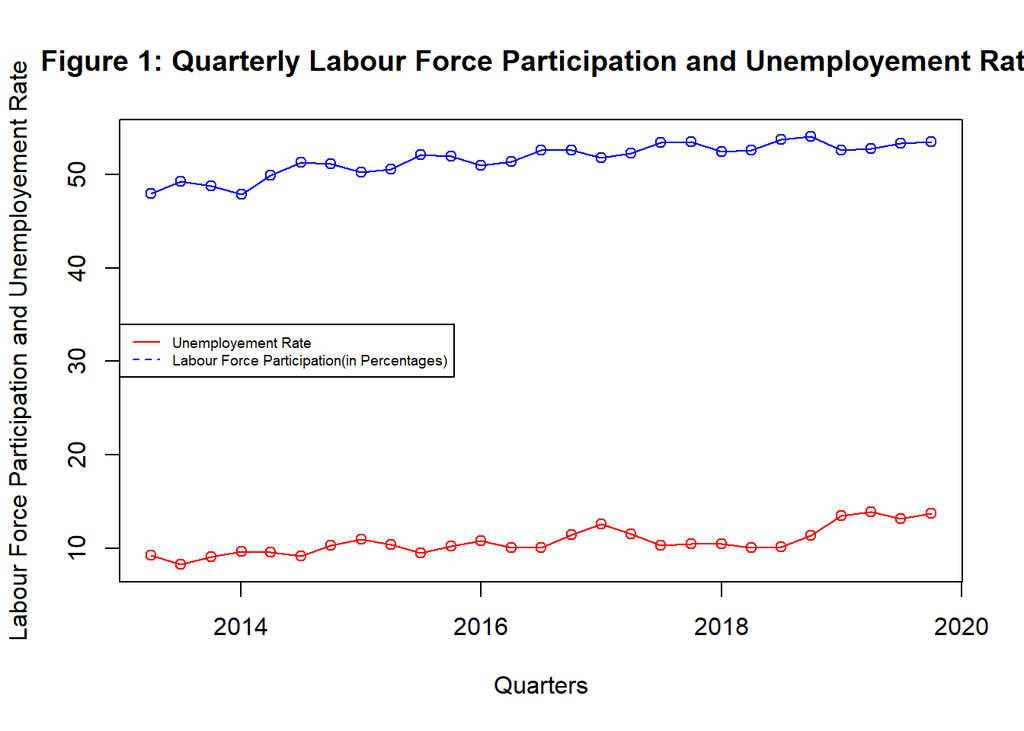

It seems like both unemployement rate and labour force participitaion increased simultaneously. To zoom in let’s plot them separately.

The unemployement rates along with non-agricultural unemployement:

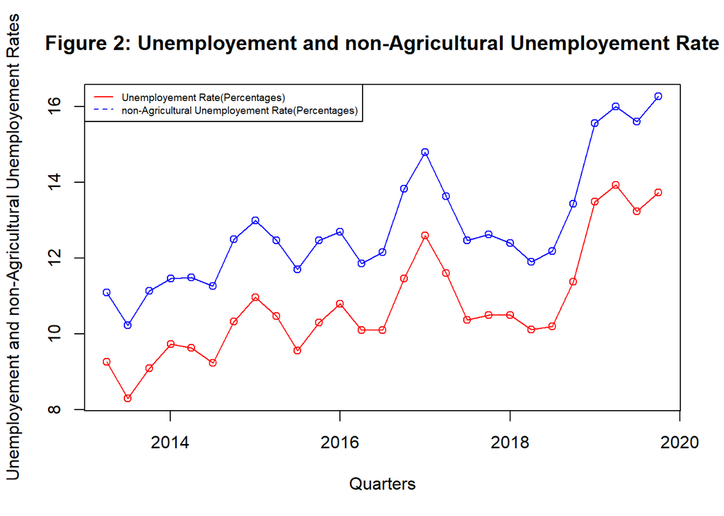

Both of these unemployement figures seem to climb from 2013 to 2020. The labour force participation, on the other hand:

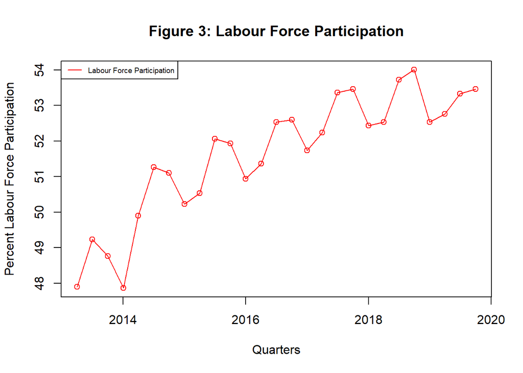

The last step to understand the financial situation of the people could be to examine consumer price index and also consumer price index for urban wage earners.

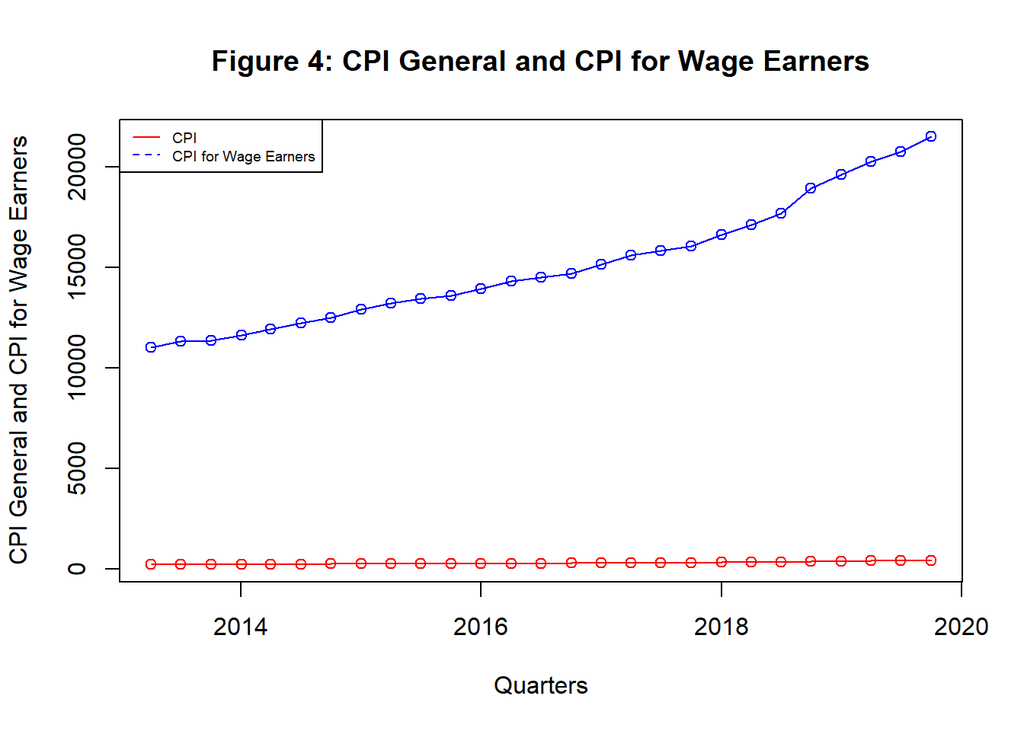

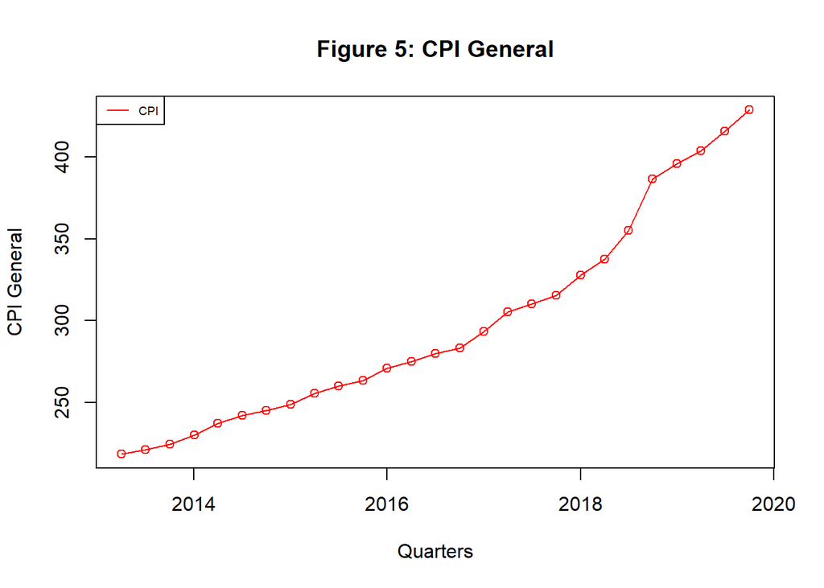

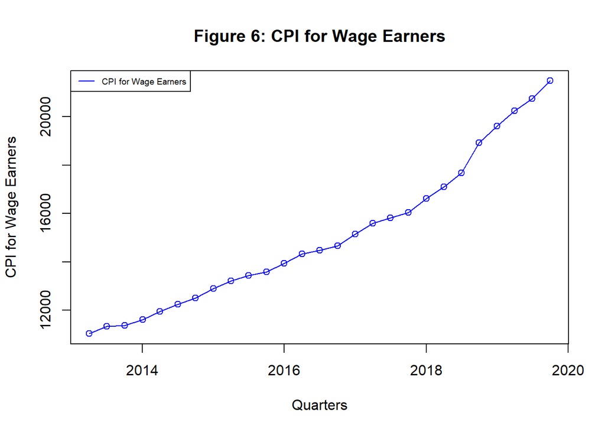

As illustrated in the graphs, the power of purchase in Turkey has been decreasing since 2013.

For the construction sector, let’s take a look at the number of house sales in total, first hand and sales to foreigners on a bar plot.

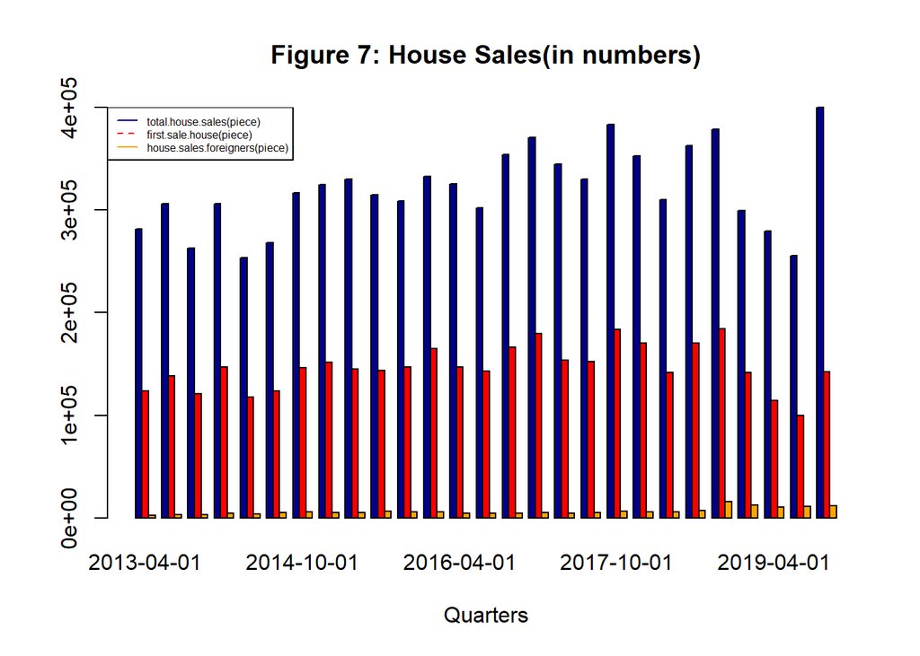

The number of houses sold to foreigners seems negligible.There seems no trend in the house sales and the first sales composes nearly half of total sales throughout the years in question.

Now, to see how the cost of purchasind a house varies over time, unit house price per square meter and Residential Property Prices Indices will be illustrated:

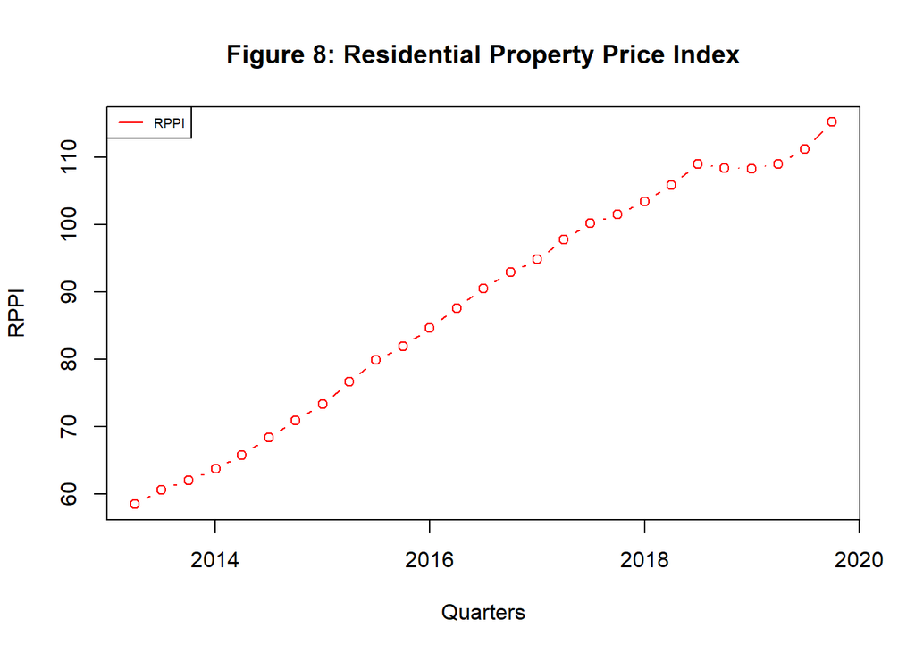

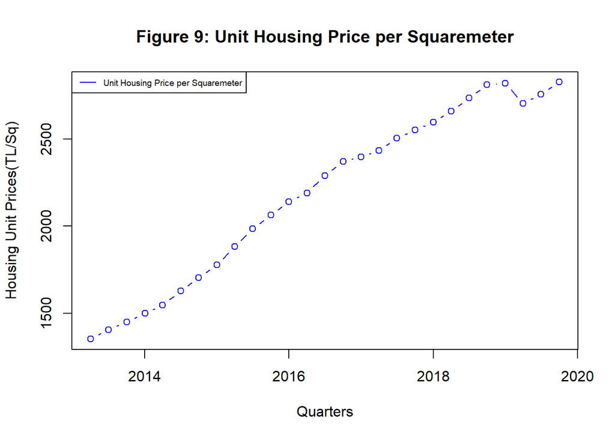

The houses in Turkey have been stably getting more expensive since 2013 in terms of both per square meter price and overall purchasing index.

Now let’s compare the RPPI and unit house prices to CPI for Wage Earners to understand if the price increase in houses is heigher than the general price increase

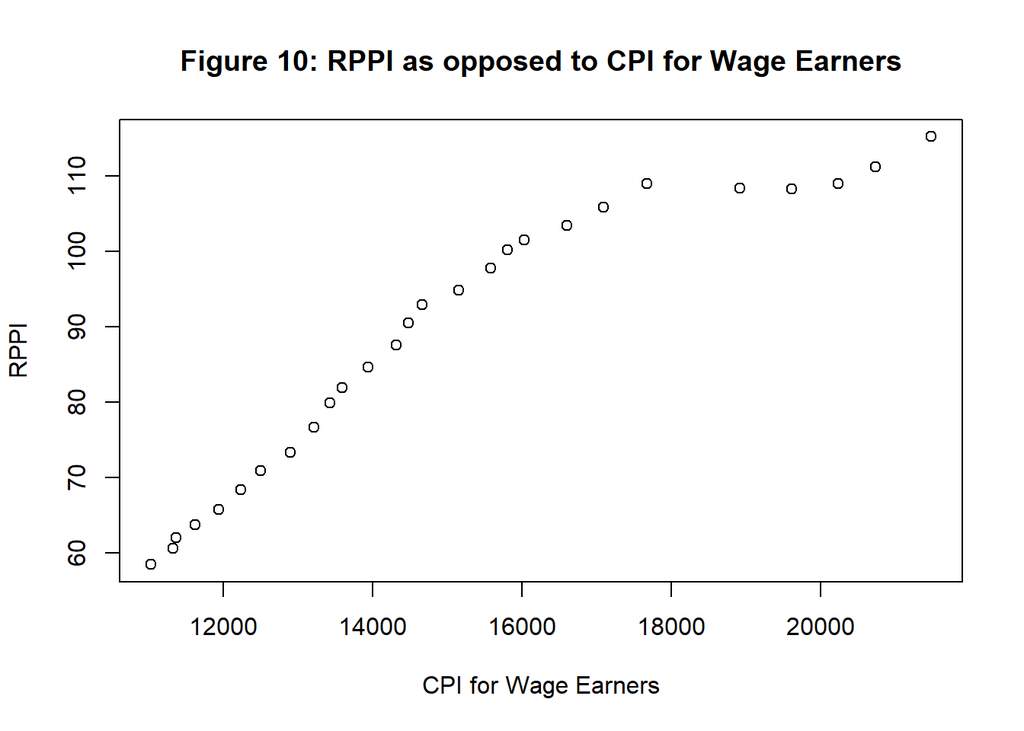

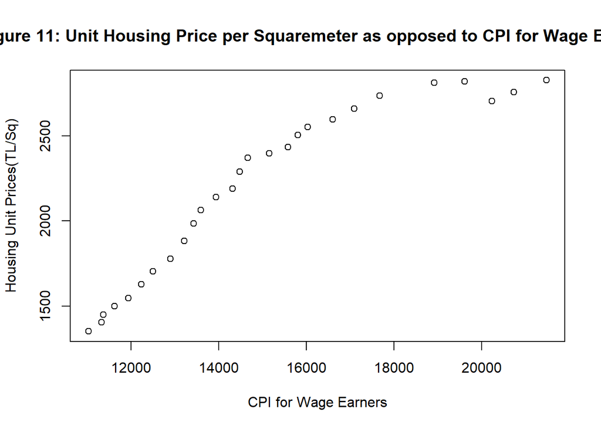

Lastly, let’s illustrate the overall GDP and GDP coming form the construction sector on a bar plot:

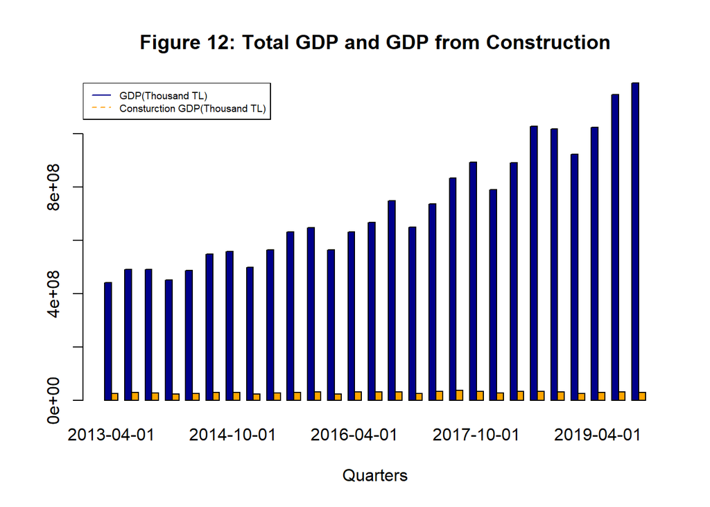

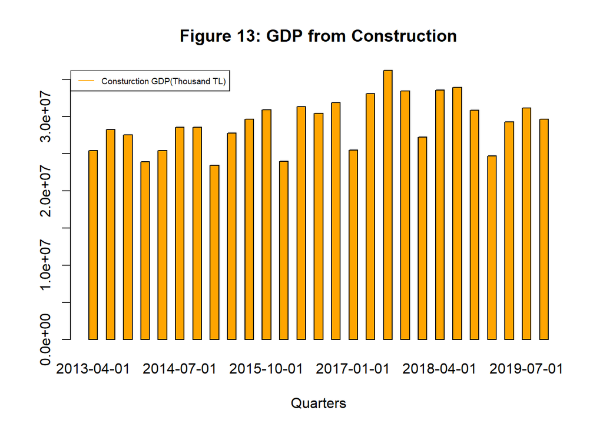

The proportion of construction sector in the GDP of Turkey has been constantly decreasing since 2013. Additionally, the production in construction sector seems to have no considerable change but seasonal fluctuations throughout the period.

# 3.Concluding Remarks

# 4. References

1. https://en.wikipedia.org/wiki/National_Mortgage_Crisis_of_the_1930s
2. https://investinganswers.com/dictionary